# 7 Nonparametric tests

- These tests are used when normality is violated
  - They do not make assumptions about the distribution of the data
- Wilcoxon signed rank test (for paired data)
- Wilcoxon rank sum test (Also called Mann-Whitney U test)

## 7.1 Examples of violation of normality assumption

## 7.2 Two sample

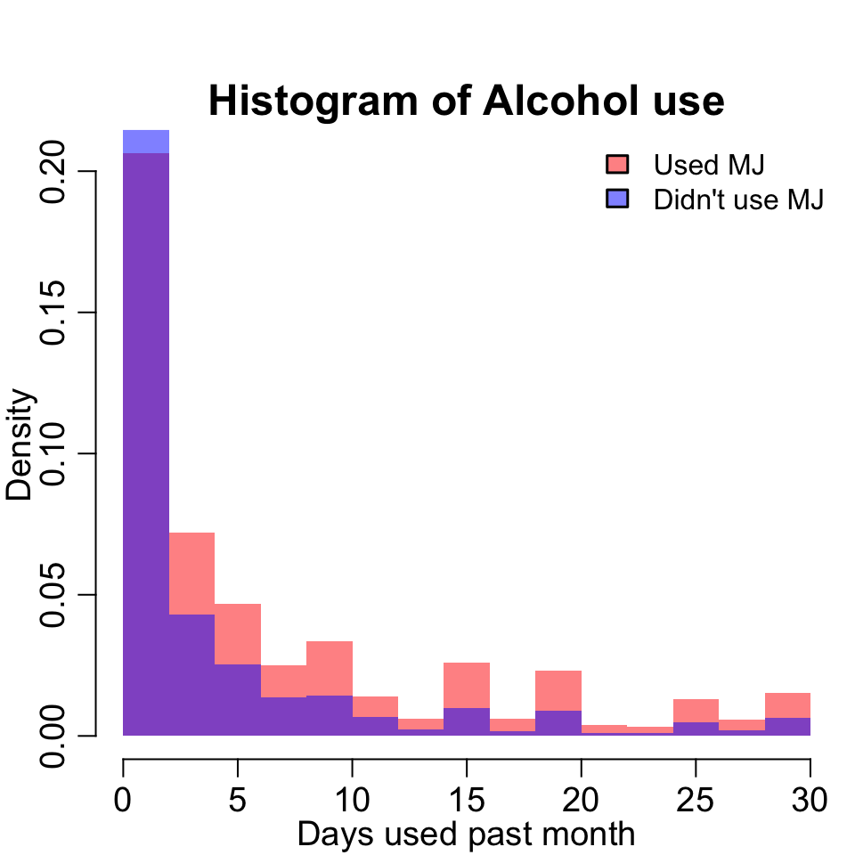

```r
histinfo = hist(puf$iralcfm, plot = FALSE, probability = TRUE)
hist(puf$iralcfm[ puf$mrjmon=='yes'], breaks = histinfo$breaks, main="Histogram of Alcohol use",
     xlab="Days used past month", col=rgb(1,0,0,.5), border=NA, probability=TRUE)
hist(puf$iralcfm[ puf$mrjmon=='no'], breaks=histinfo$breaks, col=rgb(0,0,1,.5), add=TRUE, border=NA, probability=TRUE )
legend('topright', fill=c(rgb(1,0,0,.5), rgb(0,0,1,.5)), legend=c('Used MJ', "Didn't use MJ"), bty='n')
```

## 7.3 Wilcoxon/Mann-Whitney Rank Sum Test

```r
spuf = puf[sample(nrow(puf), 100),]
# full data set test
wtestfull = wilcox.test(puf$iralcfm[ puf$mrjmon=='yes'], puf$iralcfm[ puf$mrjmon=='no'])
# subset test
wtest = wilcox.test(spuf$iralcfm[ spuf$mrjmon=='yes'], spuf$iralcfm[ spuf$mrjmon=='no'], conf.int = TRUE)

# Probability that an MJ smoker drinks more
wtest
```

```
##
##  Wilcoxon rank sum test with continuity correction
##
## data:  spuf$iralcfm[spuf$mrjmon == "yes"] and spuf$iralcfm[spuf$mrjmon == "no"]
## W = 630.5, p-value = 0.2448
## alternative hypothesis: true location shift is not equal to 0
## 95 percent confidence interval:
##  -4.033002e-05  1.000015e+00
## sample estimates:
## difference in location
##              0.9999813
```

```r
# this is the AUC
wtest$statistic/sum(spuf$mrjmon=='yes')/sum(spuf$mrjmon=='no')
```

```
##         W
## 0.5970644
```

```r
#auRoc::

# Probability that a non MJ smokers drinks more
wtest2 = wilcox.test(spuf$iralcfm[ spuf$mrjmon=='no'], spuf$iralcfm[ spuf$mrjmon=='yes'], conf.int = TRUE)
wtest$statistic/sum(spuf$mrjmon=='yes')/sum(spuf$mrjmon=='no')
```

```
##         W
## 0.5970644
```

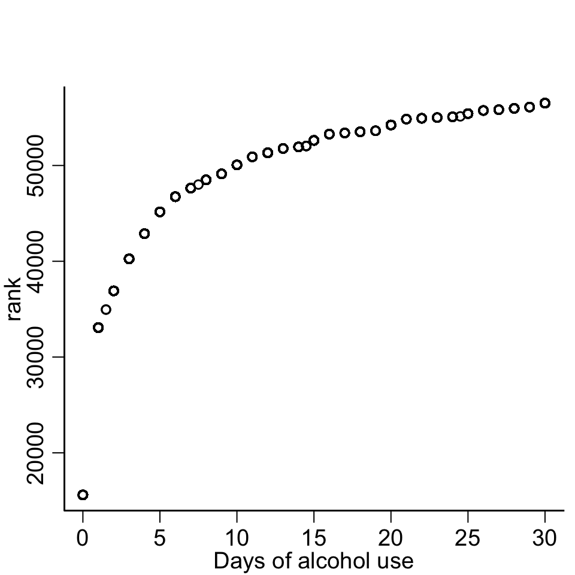

```r
plot(puf$iralcfm[puf$mrjmon=='yes'], rank(puf$iralcfm)[puf$mrjmon=='yes'], xlab='Days of alcohol use', ylab='rank')
```

```r
n1 = sum(spuf$mrjmon=='yes')
n2 = sum(spuf$mrjmon=='no')
wtestStatistic = sum(rank(spuf$iralcfm)[spuf$mrjmon=='yes']) - n1*(n1+1)/2
```

## 7.4 One sample

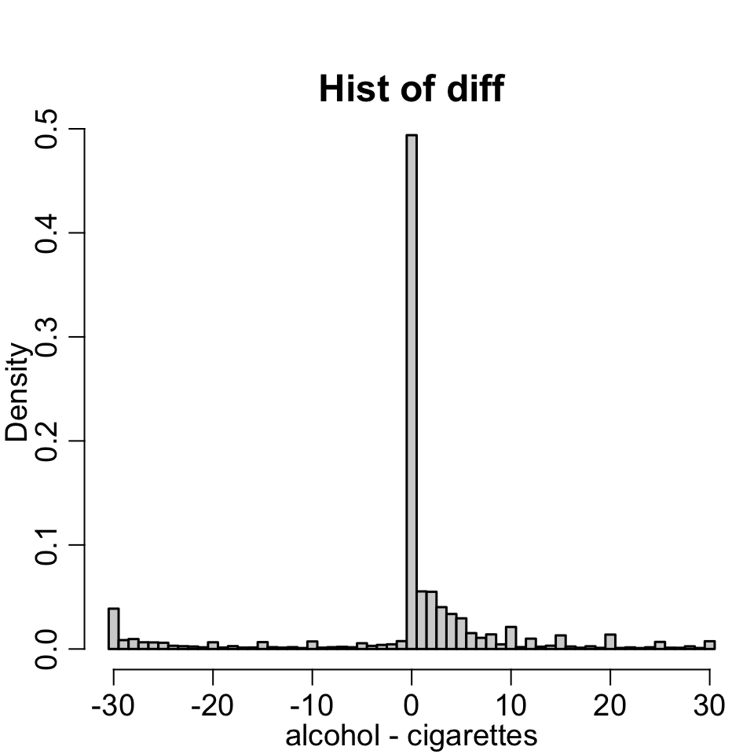

```r
diffs = round(puf$iralcfm-puf$ircigfm)
hist(diffs, xlab='alcohol - cigarettes', main='Hist of diff', freq = FALSE, breaks=seq(-30.5, 30.5, length.out=62))
```

## 7.5 Wilcoxon Signed-rank test

- This is a one-sample test (similar to the one-sample/paired t-test)
- Let’s consider the association between cigarette smoking and alcohol that we looked at before
- The normality assumption is violated here
- We also showed that the t-test is robust to this violation (meaning that the type 1 error is pretty close to where it should be)
- The signed-rank test takes the null hypothesis that the median is equal to zero (or some other chosen value)
- There are a couple different forms of the test-statistic, Wikipedia gives the formula and the variance. `R` uses the one that isn’t described on Wikipedia.
- p-values can be computed for small sample sizes exactly.
- In large samples, the test statistic is approximately normal with variance $N_r(N_r+1)(2N_r +1)/6$

```r
#descr::CrossTable(table(puf$psyanyflag, puf$illflag), chisq = TRUE)

diffs = diffs[sample(length(diffs), 100)]

wtest = wilcox.test(diffs)
wtest$statistic
```

```
##     V
## 352.5
```

```r
sdiffs = sign(diffs[ diffs !=0] )
diffsrank = rank(abs(diffs[ diffs !=0]))
nr = length(diffsrank)

# test statistic in R
statistic= sum(diffsrank[sdiffs>0])
# test statistic that has asymptotic normal distribution
Zstatistic = sum(diffsrank*sdiffs)/sqrt(nr*(nr+1)*(2*nr+1)/6)
pvalue = 2*pnorm(abs(Zstatistic), lower.tail = FALSE)

# wilcox.test result
c(wtest$statistic, wtest$p.value)
```

```
##           V
## 352.5000000   0.7995264
```

```r
# manual result, not exactly the same. May need correction for ties.
c(statistic, Zstatistic, pvalue)
```

```
## [1] 352.5000000  -0.2610410   0.7940609
```